# fork运行后可见多文件

# 简介

生成对抗网络(Generative Adversarial Network, 简称GAN) 是一种非监督学习的方式，通过让两个神经网络相互博弈的方法进行学习，该方法由lan Goodfellow等人在2014年提出。生成对抗网络由一个生成网络和一个判别网络组成，生成网络从潜在的空间(latent space)中随机采样作为输入，其输出结果需要尽量模仿训练集中的真实样本。判别网络的输入为真实样本或生成网络的输出，其目的是将生成网络的输出从真实样本中尽可能的分辨出来。而生成网络则尽可能的欺骗判别网络，两个网络相互对抗，不断调整参数。 生成对抗网络常用于生成以假乱真的图片。此外，该方法还被用于生成影片，三维物体模型等。

原始GAN与其他生成式模型相比，GAN这种竞争的方式不再要求一个假设的数据分布，即不需要formulate p(x)，而是使用一种分布直接进行采样sampling，从而真正达到理论上可以完全逼近真实数据，这也是GAN最大的优势。然而，这种不需要预先建模的方法缺点是太过自由了，对于较大的图片，较多的 pixel的情形，基于简单 GAN 的方式就不太可控了。为了解决GAN太过自由这个问题，一个很自然的想法是给GAN加一些约束，于是便有了Conditional Generative Adversarial Nets（CGAN）

CGAN，条件生成对抗网络，一种带条件约束的GAN，在生成模型（D）和判别模型（G）的建模中均引入条件变量y（conditional variable y），使用额外信息y对模型增加条件，可以指导数据生成过程。这些条件变量y可以基于多种信息，例如类别标签，用于图像修复的部分数据，来自不同模态（modality）的数据。如果条件变量y是类别标签，可以看做CGAN 是把纯无监督的 GAN 变成有监督的模型的一种改进。这个简单直接的改进被证明非常有效,并广泛用于后续的相关工作中。网络结构如下图所示：

[figure not shown]

**conditionalGAN训练19轮的模型预测效果如下图所示：**

[figure not shown]

**阅读本项目之前建议阅读原版论文**https://arxiv.org/pdf/1411.1784.pdf ，**优秀解读博客**https://blog.csdn.net/stalbo/article/details/79359380

**本项目采用minist数据集**

```python
# 代码结构
# ├── network.py   # 定义基础生成网络和判别网络。
# ├── utility.py   # 定义通用工具方法。
# └── c_gan.py     # conditionalGAN训练脚本.
# └── infer.py     # 预测脚本
# └── reader.py     # 数据读取.
```

```python
# 训练过程中，每隔固定的训练轮数，会取一个batch的数据进行测试，测试结果以图片的形式保存至--output选项指定的路径。
# 执行python c_gan.py --help可查看更多使用方式和参数详细说明。
#在GPU上训练CGAN，测试结果以图片的形式保存至--output选项指定的路径。
!python c_gan/c_gan.py --epoch=5 --output="./C_result" --use_gpu=True
```

```
2020-02-18 11:03:15,594-INFO: font search path ['/opt/conda/envs/python35-paddle120-env/lib/python3.7/site-packages/matplotlib/mpl-data/fonts/ttf', '/opt/conda/envs/python35-paddle120-env/lib/python3.7/site-packages/matplotlib/mpl-data/fonts/afm', '/opt/conda/envs/python35-paddle120-env/lib/python3.…
2020-02-18 11:03:16,011-INFO: generated new fontManager
-----------  Configuration Arguments -----------
batch_size: 128
epoch: 5
output: ./C_result
run_ce: False
use_gpu: 1
------------------------------------------------
W0218 11:03:17.667068    93 device_context.cc:236] Please NOTE: device: 0, CUDA Capability: 70, Driver API Version: 9.2, Runtime API Version: 9.0
W0218 11:03:17.672333    93 device_context.cc:244] device: 0, cuDNN Version: 7.3.
Epoch ID=0
 Batch ID=0
 D-Loss=1.4754687547683716
 DG-Loss=0.48697683215141296
 gen=[0.020384092, -0.628501, 0.8264506, -0.059517004, 0.08393577]
 Batch_time_cost=0.07
Epoch ID=0
 Batch ID=50
 D-Loss=1.3325045108795166
 DG-Loss=0.5968529582023621
 gen=[-0.32408723, -0.99999803, 0.9999368, -0.8411597, 0.089144364]
 Batch_time_cost=0.07
Epoch ID=0
 Batch ID=100
 D-Loss=1.3283110857009888
 DG-Loss=0.6360062956809998
 gen=[-0.48128778, -1.0, 0.9999977, -0.9618741, -0.15321578]
 Batch_time_cost=0.06
Epoch ID=0
 Batch ID=150
 D-Loss=1.3380171060562134
 DG-Loss=0.6329773664474487
 gen=[-0.50825375, -0.9999999, 0.99999666, -0.96668917, -0.24650867]
 Batch_time_cost=0.06
Epoch ID=0
 Batch ID=200
 D-Loss=1.3771660327911377
 DG-Loss=0.6287590861320496
 gen=[-0.48687252, -0.99999964, 0.99999994, -0.96308786, -0.18785018]
```

[output cut: 256 more lines]

```
 DG-Loss=0.6400759220123291
 gen=[-0.7066042, -1.0, 1.0, -0.99998295, -0.9380742]
 Batch_time_cost=0.06
Epoch ID=4
 Batch ID=400
 D-Loss=1.3609528541564941
 DG-Loss=0.6274992823600769
 gen=[-0.7641589, -1.0, 1.0, -0.99999577, -0.97579837]
 Batch_time_cost=0.06
Epoch ID=4
 Batch ID=450
 D-Loss=1.3415582180023193
 DG-Loss=0.652595043182373
 gen=[-0.7490909, -1.0, 1.0, -0.9999947, -0.97528887]
 Batch_time_cost=0.06
```

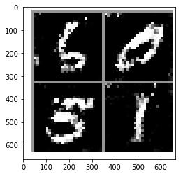

```python
#使用固化后的模型(训练了5轮)进行预测，预测结果保存在output中，batch_size为生成图像个数
!python c_gan/infer.py --output="./infer_result" --use_gpu=True --batch_size=4

# 可视化预测效果
%matplotlib inline
import matplotlib.pyplot as plt
import numpy as np
import cv2

img= cv2.imread('infer_result/generated_image.png')
plt.imshow(img)
plt.show()
```